**Econometrics: Methods and Applications** Erasmus University Rotterdam https://www.coursera.org/learn/erasmus-econometrics/home/welcome

# Training Exercise 1.2

> Dataset TrainExer13 contains the winning times (W) of the Olympic 100-meter finals (for men) from 1948 to 2004.

> The calendar years 1948-2004 are transformed to games (G) 1-15 to simplify computations. A simple regression model for the trend in winning times is $W_i=\alpha + \beta G_i + \epsilon_i$

> (a) Compute $\alpha$ and $\beta$, and determine the values of $R^2$ and $s$

> (b) Are you confident on the predictive ability of this model? Motivate your answer.

> (c) What prediction do you get for 2008, 2012, and 2016? Compare your predictions with the actual winning times.

```python
import numpy as np
import pandas as pd
from sklearn.linear_model import LinearRegression
import matplotlib.pyplot as plt
```

- https://pandas.pydata.org/docs/reference/api/pandas.read_csv.html
- https://pandas.pydata.org/docs/getting_started/intro_tutorials/03_subset_data.html
- https://numpy.org/doc/stable/reference/generated/numpy.reshape.html
- https://numpy.org/doc/stable/user/basics.creation.html
- https://scikit-learn.org/stable/modules/generated/sklearn.linear_model.LinearRegression.html
- https://matplotlib.org/stable/gallery/statistics/hist.html

```python
TrainExer13 = pd.read_csv('TrainExer13.txt', sep='\t', header=0, names=['G', 'T'], index_col=1)
```

```python
TrainExer13
```

|  | G | T |
| --- | --- | --- |
| 1948 | 1 | 10.30 |
| 1952 | 2 | 10.40 |
| 1956 | 3 | 10.50 |
| 1960 | 4 | 10.20 |
| 1964 | 5 | 10.00 |
| 1968 | 6 | 9.95 |
| 1972 | 7 | 10.14 |
| 1976 | 8 | 10.06 |
| 1980 | 9 | 10.25 |
| 1984 | 10 | 9.99 |
| 1988 | 11 | 9.92 |
| 1992 | 12 | 9.96 |
| 1996 | 13 | 9.84 |
| 2000 | 14 | 9.87 |
| 2004 | 15 | 9.85 |

```python
X = pd.Series.to_numpy(TrainExer13['G']).reshape((-1, 1))
```

```python
y = pd.Series.to_numpy(TrainExer13['T'])
```

```python
model = LinearRegression().fit(X, y)
```

```python
model.intercept_
```

```
10.386000000000001
```

```python
model.coef_
```

```
array([-0.038])
```

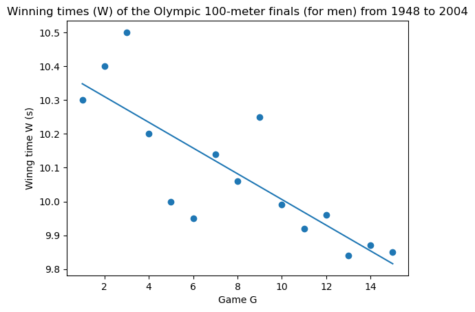

```python
plt.scatter(X,y)
plt.plot(X, model.predict(X))
plt.xlabel('Game G')
plt.ylabel('Winng time W (s)')
plt.title('Winning times (W) of the Olympic 100-meter finals (for men) from 1948 to 2004')
```

```python
residuals = y - model.predict(X)
```

```python
s = np.sum(np.square(residuals)) / (y.size - 2)
```

```python
s
```

```
0.015086153846153952
```

```python
r_sq = model.score(X, y)
```

```python
r_sq
```

```
0.6733728599027362
```

```python
model.predict(np.array([16,]).reshape((-1,1)))
```

```
array([9.778])
```

```python
model.predict(np.array([17,]).reshape((-1,1)))
```

```
array([9.74])
```

```python
model.predict(np.array([18,]).reshape((-1,1)))
```

```
array([9.702])
```

https://olympics.com/en/olympic-games/olympic-results

Olympic Games Beijing 2008: 9.890 https://olympics.com/en/olympic-games/beijing-2008/results/athletics/100m-men

Olympic Games London 2012: 9.630 https://olympics.com/en/olympic-games/london-2012/results/athletics/100m-men

Olympic Games Rio 2016: 9.810 https://olympics.com/en/olympic-games/rio-2016/results/athletics/100m-men

```python
print("Residual for 2008 prediction is " + str(9.890 - 9.778))
```

```
Residual for 2008 prediction is 0.1120000000000001
```

```python
print("Residual for 2008 prediction is " + str(9.630 - 9.74))
```

```
Residual for 2008 prediction is -0.10999999999999943
```

```python
print("Residual for 2008 prediction is " + str(9.810 - 9.702))
```

```
Residual for 2008 prediction is 0.10800000000000054
```

Any model of a quantity that cannot be negative, such as duration of 100m race, will eventually break down. But beyond this a priori limited domain, one weakness of this model is that despite residuals being equally spread between positive and negative, the absolute size of the residuals is decreasing as G increases: there are large residuals for lower $G$, and small residuals for higher $G$. This is a symptom of a bad model.